# HW4-Predictive regression modeling with R

misken

February 9, 2018

## Step 1 - Familiarize yourself with the data and the assignment

In this assignment you'll build some predictive regression models with R on a dataset containing inpatient discharges from hospitals in New York.

The version of this data that we'll be using is from a Kaggle dataset. See https://www.kaggle.com/jonasalmeida/2015-deidentified-ny-inpatient-discharge-sparcs. Unfortunately, the column metadata wasn't posted. However, since this is a publicly available dataset, we can visit the source at https://health.data.ny.gov/Health/Hospital-Inpatient-Discharges-SPARCS-De-Identified/82xm-y6g8.

If you scroll down on that page you'll find descriptions of the columns (click the little Show All link to display the entire list).

Most of the fields are self-explanatory. You'll notice that there are several sets of diagnosis and procedure codes. A few definitions are helpful.

### DRG - Diagnosis Related Groups

DRGs are a coding system developed in the 1980s that form the basis of how hospitals are reimbursed from Medicare (US Govt) or private insurers. After a patient is discharged from the hospital, a program known as a *DRG grouper* uses information such as diagnosis and procedure codes (ICD-9-CM) to assign a DRG to the patient. A full list of the over 900 DRGs can be found at:

https://www.cms.gov/Research-Statistics-Data-and-Systems/Statistics-Trends-and-Reports/MedicareFeeforSvcPartsAB/downloads/DRGdesc08.pdf

In that list you'll see that MDC (Medical Diagnostic Category) is simply a grouping of DRGs.

### CCS - Clinical Classification System

The [CCS](https://www.hcup-us.ahrq.gov/toolssoftware/ccs/ccs.jsp) system was developed by the [Agency for Healthcare Research and Quality (AHRQ)](https://www.ahrq.gov/) to provide a classification system better suited to healthcare research. There are CCS diagnosis codes and CCS procedure codes. From their website:

> The Clinical Classifications Software (CCS) for ICD-9-CM is a diagnosis and procedure categorization scheme that can be employed in many types of projects analyzing data on diagnoses and procedures. CCS is based on the International Classification of Diseases, 9th Revision, Clinical Modification (ICD-9-CM), a uniform and standardized coding system. The ICD-9-CM's multitude of codes - over 14,000 diagnosis codes and 3,900 procedure codes - are collapsed into a smaller number of clinically meaningful categories that are sometimes more useful for presenting descriptive statistics than are individual ICD-9-CM codes.

As we did in class, you'll be creating an R Markdown document to do the analysis as well as to document the steps you did (and answer some questions I'll throw at you).

You'll notice a few "Hacker Extra" tasks thrown in. These are for those of you who want to go a little above and beyond and attempt some more challenging tasks.

## Step 2 - Create a new R Markdown document

Save this file as a new R Markdown document and name it something that includes your last name in the filename. Save it into the same folder as this file.

## Step 3 - Create project and load data

Create an R Studio project in the current folder (the one containing this file). You'll notice that there is a folder named **data**. Inside of it you'll find the data file for this assignment:

- **ipd_resp.RData**

The full dataset contains over two million records and is available as a CSV file from Kaggle. I did a little data filtering and cleaning to create a subset to use for this regression assignment. Specifically, I did the following:

- used dplyr to filter records so that we were just working with `APR MDC Code` == 4. These are patients having respiratory related diagnoses.
- a bunch of fields were read in as `chr` and I changed them to factors using `as.factor`.
- There were some fields we don't need and they were dropped.
- Just as in HW1, I cleaned up the charges and costs fields that got interpreted as `chr` because of the leading dollar sign. Now they are numeric.
- Modified some field names to make them easier to work with.

See the data prep script for all the details. You do **NOT** need to run the data prep script. I'm just including it so you can see a typical data prep script.

### Load the data

```r
load("./data/ipd_resp.RData")
#str(ipd_resp)
ipd_resp <- droplevels(ipd_resp) #Removed unused factor levels
```

## Step 4 - Partition into training and test sets

Just run this chunk to create training and test datasets. This way we'll all be working with the same datasets. Notice that the test set is 30% of the full dataset.

```r
set.seed(1828)
sample_size <- ceiling(0.30 * nrow(ipd_resp))
testrecs <- sample(nrow(ipd_resp),sample_size)
ipd_test <- ipd_resp[testrecs,]
ipd_train <- ipd_resp[-testrecs,]  # Negative in front of vector means "not in"
rm(ipd_resp) # No sense keeping a copy of the entire dataset around
```

## Step 5 - EDA on training data

Now start with some EDA on the training dataset`ipd_train`. The test data will only get used after building models and want to compare their predictive abilities.

You'll notice that `ipd_train` contains a few numeric fields and many factors (categorical data). You are free to use any of these fields in your regression models to predict `Total_Charges`.

Start by using things like ggplot2 and dplyr to explore the training dataset. You can use other packages as well. Your goal is to gain a general understanding of the variables and perhaps uncover some useful relationships that you can use in your regression models.

**NOTE: In the data prep phase I made sure there were no NA values in the data frames that we are using for this assignment. So, no need to worry about that.**

```r
library(dplyr)
```

```r
library(ggplot2)
```

```r
summary(ipd_train)
```

```
##      Health_Service_Area  Hospital_County   Facility_Id
##  New York City :59355    Manhattan:17112   1169   :  3769
##  Long Island   :18906    Kings    :14286   1464   :  2655
##  Hudson Valley :14989    Bronx    :13883   1172   :  2517
##  Capital/Adiron:11629    Queens   :10931   1178   :  2341
##  Central NY    :10770    Suffolk  : 9603   1458   :  2091
##  Western NY    :10456    Nassau   : 9303   413    :  2013
##  (Other)       :11215    (Other)  :62202   (Other):121934
##                                                         Facility_Name
##  Montefiore Medical Center - Henry & Lucy Moses Div            :  3769
##  New York Presbyterian Hospital - Columbia Presbyterian Center :  2655
##  Lincoln Medical & Mental Health Center                        :  2517
##  Bronx-Lebanon Hospital Center - Concourse Division            :  2341
##  New York Presbyterian Hospital - New York Weill Cornell Center:  2091
##  Good Samaritan Hospital Medical Center                        :  2013
##  (Other)                                                       :121934
##        Age_Group        ZipCode      Gender
##  0 to 17    :18955   112    :16184   F:72465
##  18 to 29   : 4410   104    :15118   M:64855
##  30 to 49   :13174   117    :10422
##  50 to 69   :44726   100    : 8879
##  70 or Older:56055   113    : 6190
##                      115    : 4771
##                      (Other):75756
##                      Race                   Ethnicity
##  Black/African American:26759   Multi-ethnic     :   533
##  Multi-racial          : 1248   Not Span/Hispanic:114997
##  Other Race            :28283   Spanish/Hispanic : 16107
##  White                 :81030   Unknown          :  5683
##
##
##
##  Length_of_Stay        Type_of_Admission
##  Min.   :  1.000   Elective     :  7833
##  1st Qu.:  2.000   Emergency    :123327
##  Median :  4.000   Newborn      :    15
##  Mean   :  5.591   Not Available:    56
##  3rd Qu.:  7.000   Trauma       :   391
##  Max.   :119.000   Urgent       :  5698
##
```

[output cut: 41 more lines]

```
##  Extreme :14310               Extreme : 9920
##  Major   :46752               Major   :36936
##  Minor   :23375               Minor   :50734
##  Moderate:52883               Moderate:39730
##
##
##
##                  Payment_Typology_1 Total_Charges      Total_Costs
##  Medicare                 :72837    Min.   :      1   Min.   :     0.6
##  Medicaid                 :34848    1st Qu.:  13190   1st Qu.:  5283.6
##  Private Health Insurance :12315    Median :  24485   Median :  8998.8
##  Blue Cross/Blue Shield   :10478    Mean   :  41551   Mean   : 15527.7
##  Self-Pay                 : 3150    3rd Qu.:  46436   3rd Qu.: 16499.2
##  Managed Care, Unspecified: 1292    Max.   :2691248   Max.   :689872.8
##  (Other)                  : 2400
```

Now, it's your turn ...

```r
ipd_train$ProcDone <- as.factor(ifelse(ipd_train$CCS_Proc_Code==0, "No", "Yes"))
ipd_test$ProcDone <- as.factor(ifelse(ipd_test$CCS_Proc_Code==0, "No", "Yes"))
summary(ipd_train$ProcDone)
```

```
##    No   Yes
## 55683 81637
```

```r
ipd_train$LogCharge <- log10(ipd_train$Total_Charges)
ipd_test$LogCharge <- log10(ipd_test$Total_Charges)
```

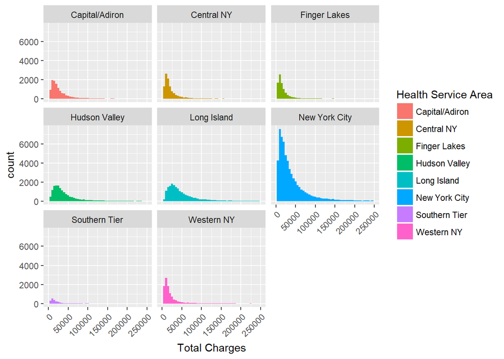

```r
ggplot(ipd_train, aes(x = Total_Charges, fill = Health_Service_Area)) +
  geom_histogram(binwidth = 5000) +
  scale_x_continuous(limits = c(0, 250000)) +
  labs(x = "Total Charges", fill = "Health Service Area") +
  theme(axis.text.x = element_text(angle = 45, hjust = 1)) +
  facet_wrap(~Health_Service_Area)
```

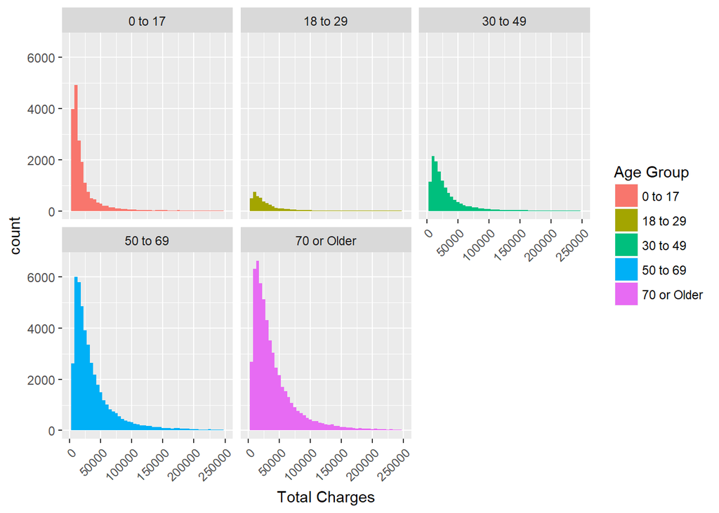

```r
ggplot(ipd_train, aes(x = Total_Charges, fill = Age_Group)) +
  geom_histogram(binwidth = 5000) +
  scale_x_continuous(limits = c(0, 250000)) +
  labs(x = "Total Charges", fill = "Age Group") +
  theme(axis.text.x = element_text(angle = 45, hjust = 1)) +
  facet_wrap(~Age_Group)
```

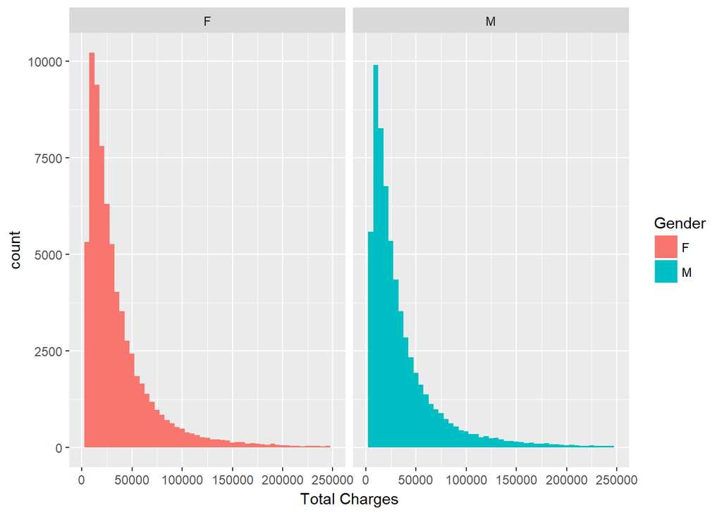

```r
ggplot(ipd_train, aes(x = Total_Charges, fill = Gender)) +
  geom_histogram(binwidth = 5000) +
  scale_x_continuous(limits = c(0, 250000)) +
  labs(x = "Total Charges", fill = "Gender") +
  facet_wrap(~Gender)
```

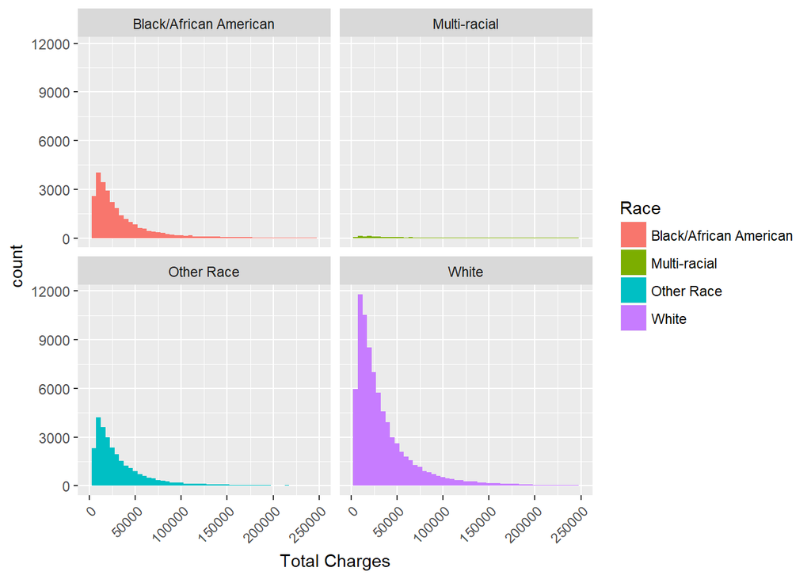

```r
ggplot(ipd_train, aes(x = Total_Charges, fill = Race)) +
  geom_histogram(binwidth = 5000) +
  scale_x_continuous(limits = c(0, 250000)) +
  labs(x = "Total Charges", fill = "Race") +
  theme(axis.text.x = element_text(angle = 45, hjust = 1)) +
  facet_wrap(~Race)
```

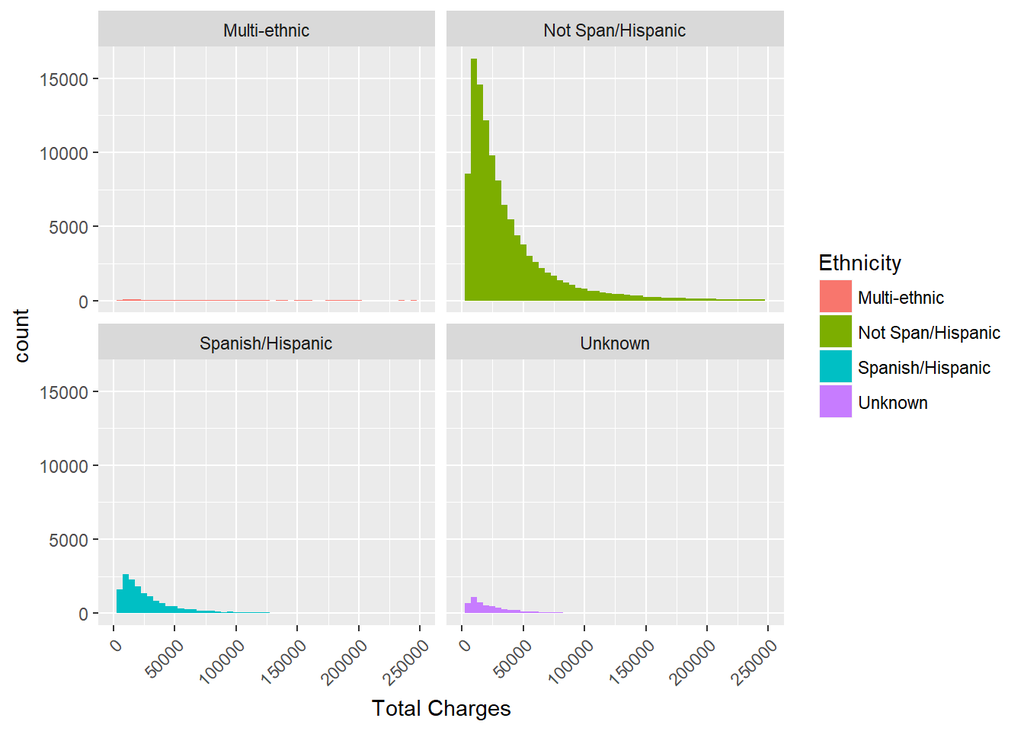

```r
ggplot(ipd_train, aes(x = Total_Charges, fill = Ethnicity)) +
  geom_histogram(binwidth = 5000) +
  scale_x_continuous(limits = c(0, 250000)) +
  labs(x = "Total Charges", fill = "Ethnicity") +
  theme(axis.text.x = element_text(angle = 45, hjust = 1)) +
  facet_wrap(~Ethnicity)
```

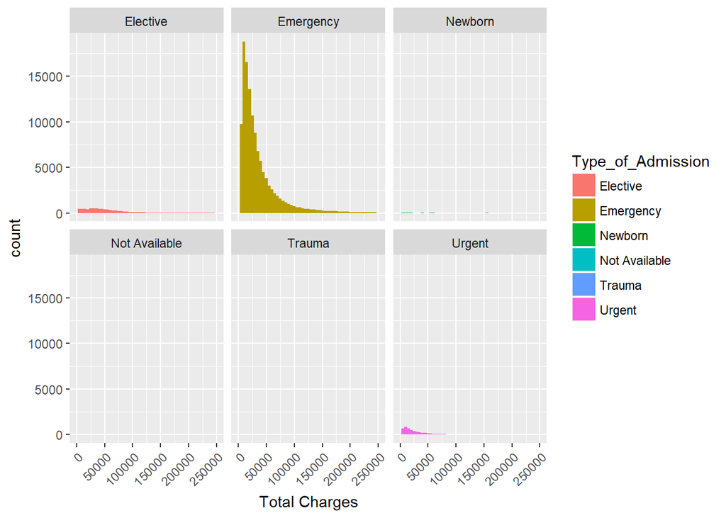

```r
ggplot(ipd_train, aes(x = Total_Charges, fill = Type_of_Admission)) +
  geom_histogram(binwidth = 5000) +
  scale_x_continuous(limits = c(0, 250000)) +
  labs(x = "Total Charges", fill = "Type_of_Admission") +
  theme(axis.text.x = element_text(angle = 45, hjust = 1)) +
  facet_wrap(~Type_of_Admission)
```

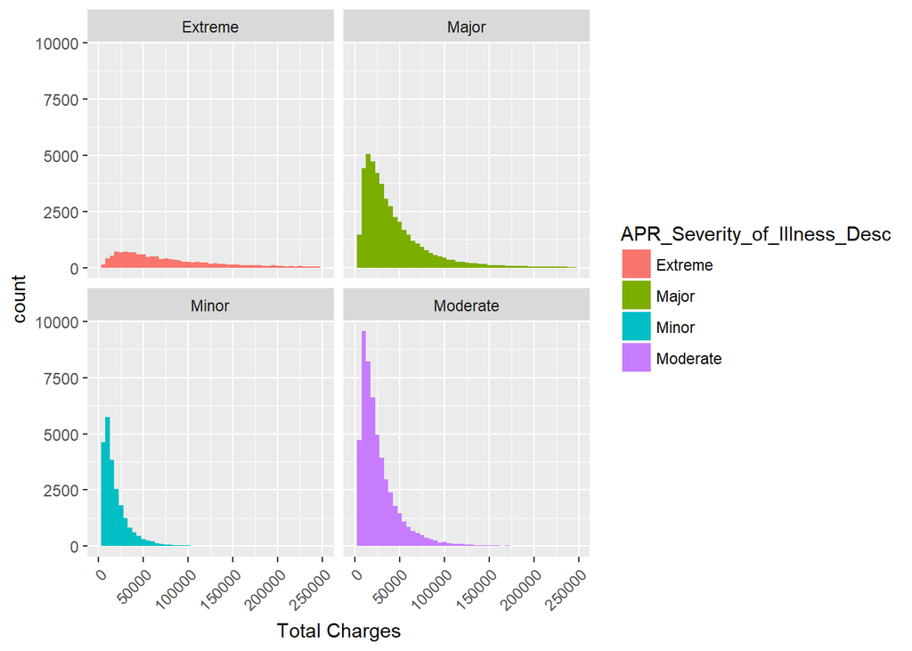

```r
ggplot(ipd_train, aes(x = Total_Charges, fill = APR_Severity_of_Illness_Desc)) +
  geom_histogram(binwidth = 5000) +
  scale_x_continuous(limits = c(0, 250000)) +
  labs(x = "Total Charges", fill = "APR_Severity_of_Illness_Desc") +
  theme(axis.text.x = element_text(angle = 45, hjust = 1)) +
  facet_wrap(~APR_Severity_of_Illness_Desc)
```

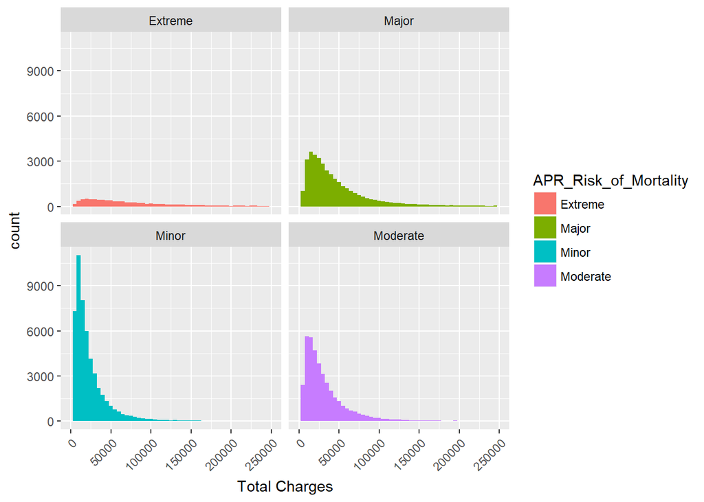

```r
ggplot(ipd_train, aes(x = Total_Charges, fill = APR_Risk_of_Mortality)) +
  geom_histogram(binwidth = 5000) +
  scale_x_continuous(limits = c(0, 250000)) +
  labs(x = "Total Charges", fill = "APR_Risk_of_Mortality") +
  theme(axis.text.x = element_text(angle = 45, hjust = 1)) +
  facet_wrap(~APR_Risk_of_Mortality)
```

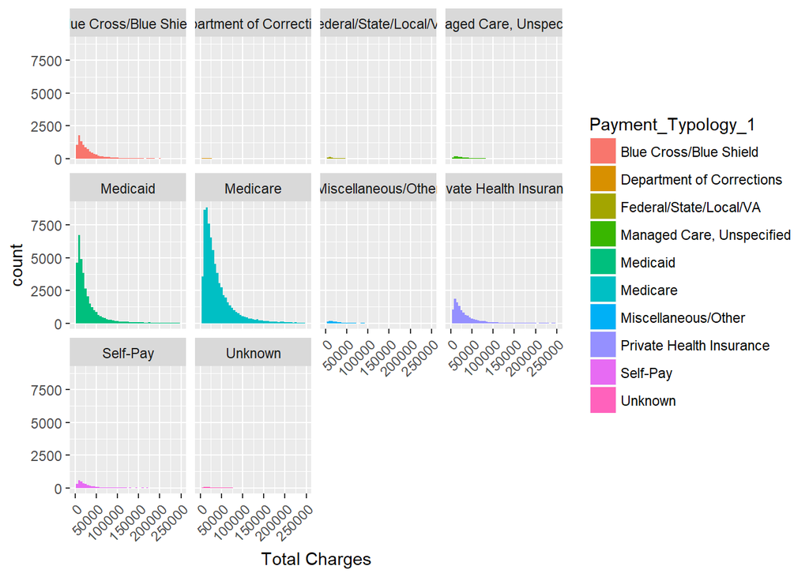

```r
ggplot(ipd_train, aes(x = Total_Charges, fill = Payment_Typology_1)) +
  geom_histogram(binwidth = 5000) +
  scale_x_continuous(limits = c(0, 250000)) +
  labs(x = "Total Charges", fill = "Payment_Typology_1") +
  theme(axis.text.x = element_text(angle = 45, hjust = 1)) +
  facet_wrap(~Payment_Typology_1)
```

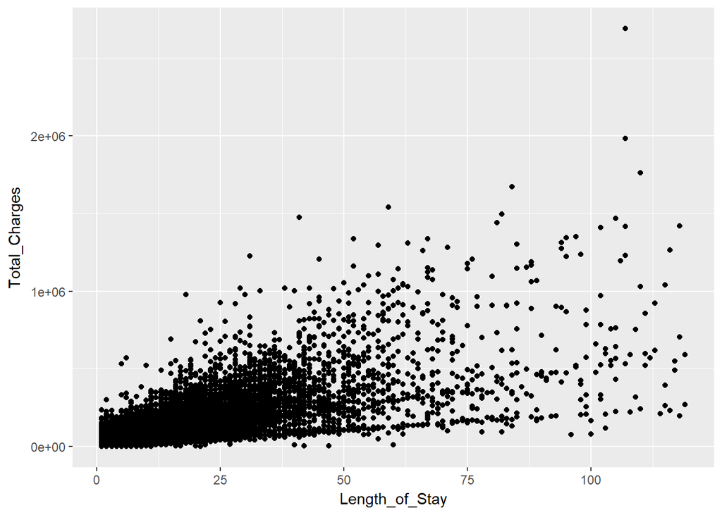

```r
ggplot(ipd_train, aes( x = Length_of_Stay, y = Total_Charges)) +
  geom_point()
```

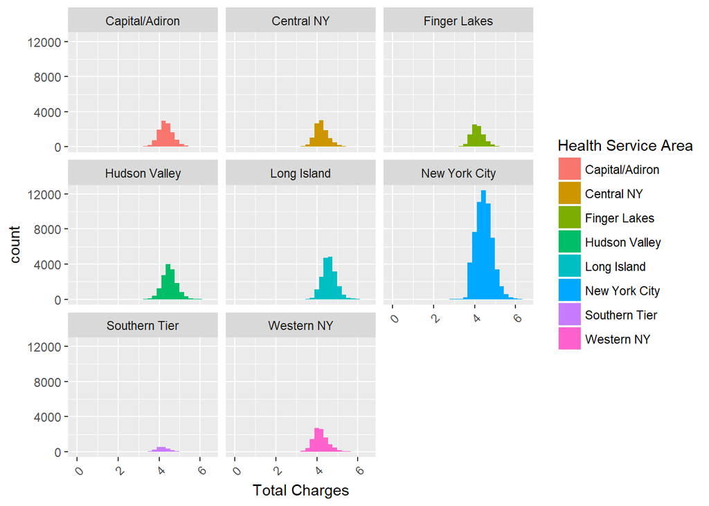

```r
ggplot(ipd_train, aes(x = LogCharge, fill = Health_Service_Area)) +
  geom_histogram() +
  labs(x = "Total Charges", fill = "Health Service Area") +
  theme(axis.text.x = element_text(angle = 45, hjust = 1)) +
  facet_wrap(~Health_Service_Area)
```

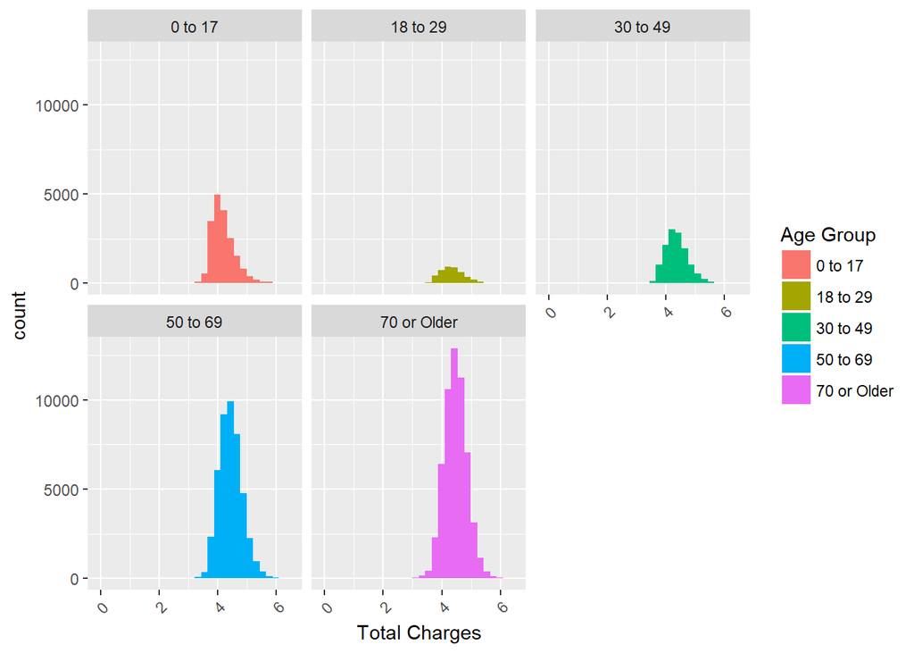

```r
ggplot(ipd_train, aes(x = LogCharge, fill = Age_Group)) +
  geom_histogram() +
  labs(x = "Total Charges", fill = "Age Group") +
  theme(axis.text.x = element_text(angle = 45, hjust = 1)) +
  facet_wrap(~Age_Group)
```

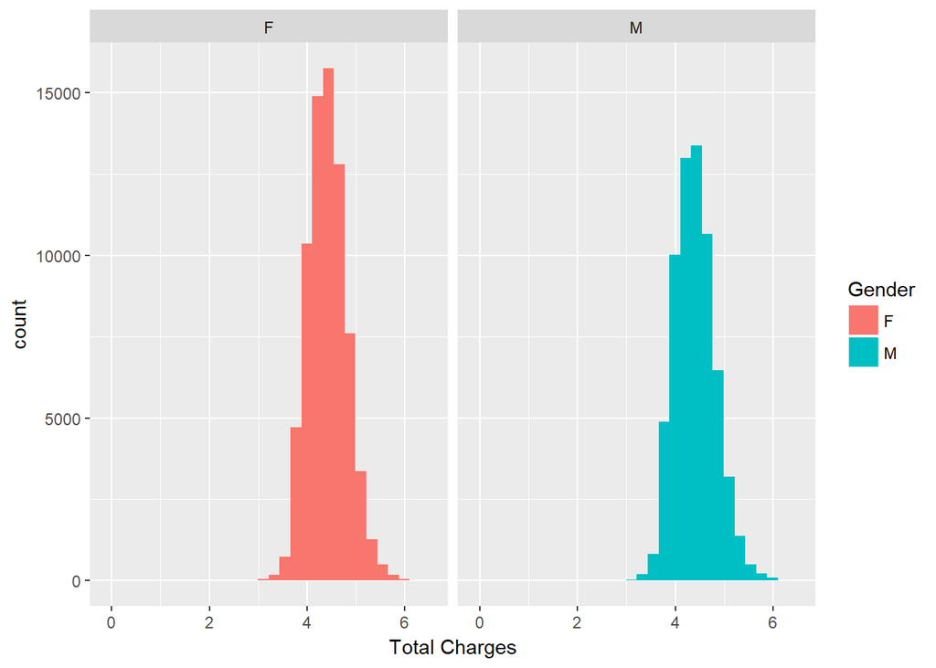

```r
ggplot(ipd_train, aes(x = LogCharge, fill = Gender)) +
  geom_histogram() +
  labs(x = "Total Charges", fill = "Gender") +
  facet_wrap(~Gender)
```

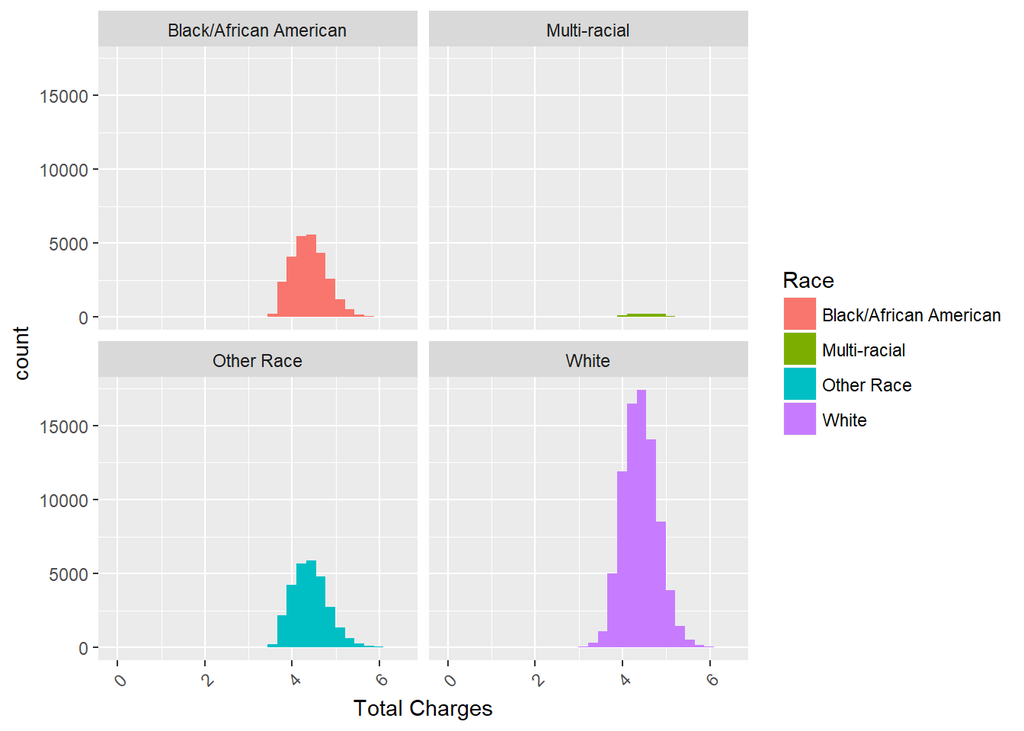

```r
ggplot(ipd_train, aes(x = LogCharge, fill = Race)) +
  geom_histogram() +
  labs(x = "Total Charges", fill = "Race") +
  theme(axis.text.x = element_text(angle = 45, hjust = 1)) +
  facet_wrap(~Race)
```

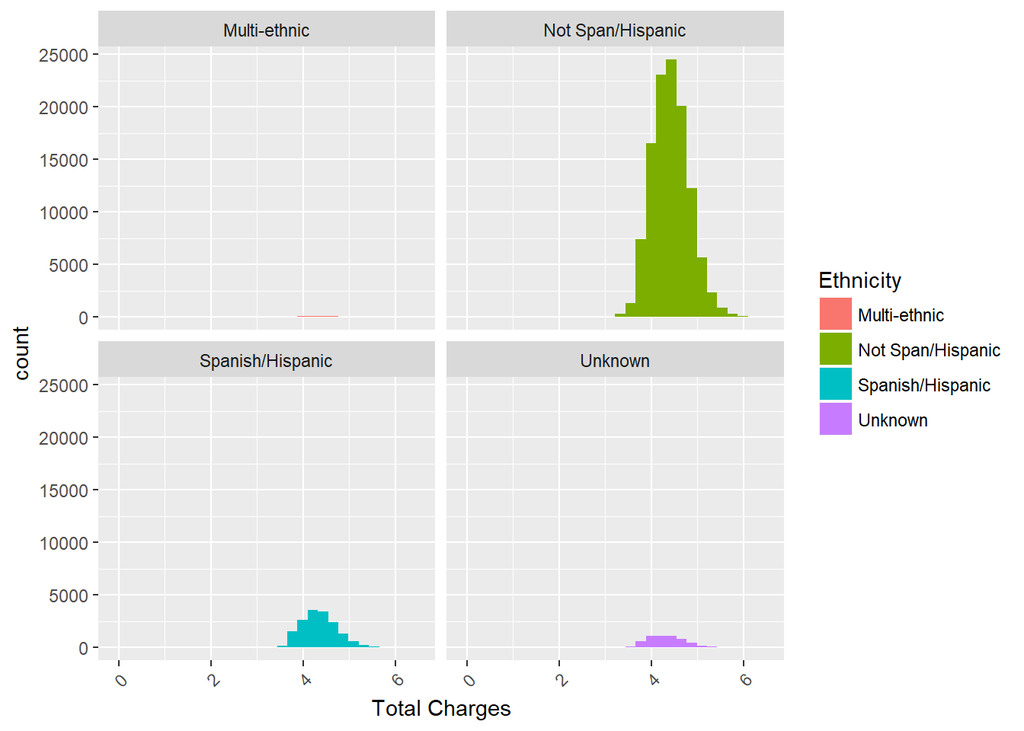

```r
ggplot(ipd_train, aes(x = LogCharge, fill = Ethnicity)) +
  geom_histogram() +
  labs(x = "Total Charges", fill = "Ethnicity") +
  theme(axis.text.x = element_text(angle = 45, hjust = 1)) +
  facet_wrap(~Ethnicity)
```

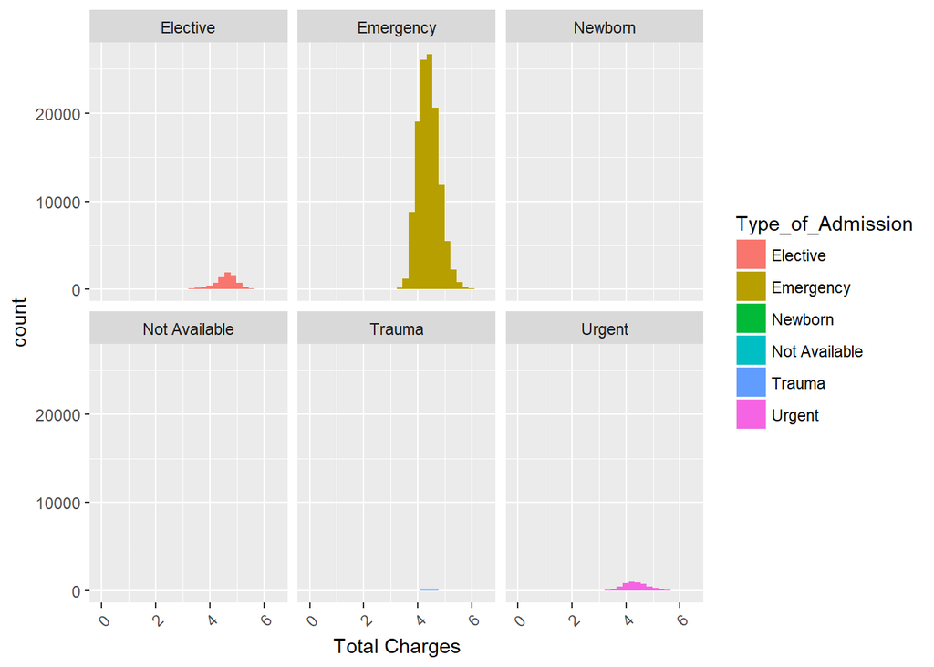

```r
ggplot(ipd_train, aes(x = LogCharge, fill = Type_of_Admission)) +
  geom_histogram() +
  labs(x = "Total Charges", fill = "Type_of_Admission") +
  theme(axis.text.x = element_text(angle = 45, hjust = 1)) +
  facet_wrap(~Type_of_Admission)
```

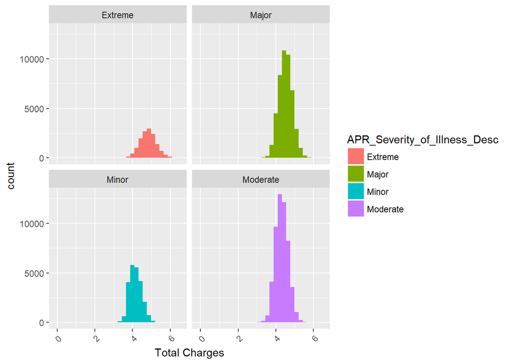

```r
ggplot(ipd_train, aes(x = LogCharge, fill = APR_Severity_of_Illness_Desc)) +
  geom_histogram() +
  labs(x = "Total Charges", fill = "APR_Severity_of_Illness_Desc") +
  theme(axis.text.x = element_text(angle = 45, hjust = 1)) +
  facet_wrap(~APR_Severity_of_Illness_Desc)
```

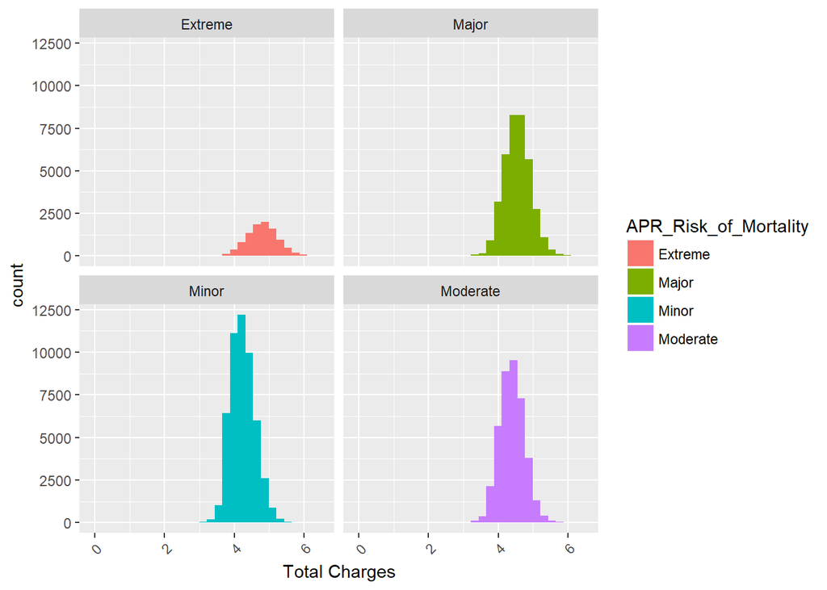

```r
ggplot(ipd_train, aes(x = LogCharge, fill = APR_Risk_of_Mortality)) +
  geom_histogram() +
  labs(x = "Total Charges", fill = "APR_Risk_of_Mortality") +
  theme(axis.text.x = element_text(angle = 45, hjust = 1)) +
  facet_wrap(~APR_Risk_of_Mortality)
```

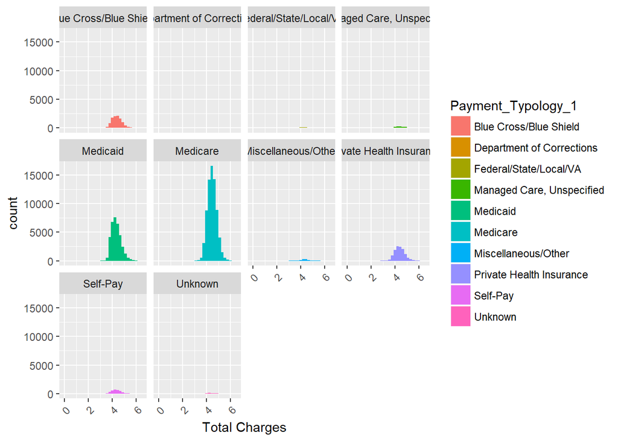

```r
ggplot(ipd_train, aes(x = LogCharge, fill = Payment_Typology_1)) +
  geom_histogram() +
  labs(x = "Total Charges", fill = "Payment_Typology_1") +
  theme(axis.text.x = element_text(angle = 45, hjust = 1)) +
  facet_wrap(~Payment_Typology_1)
```

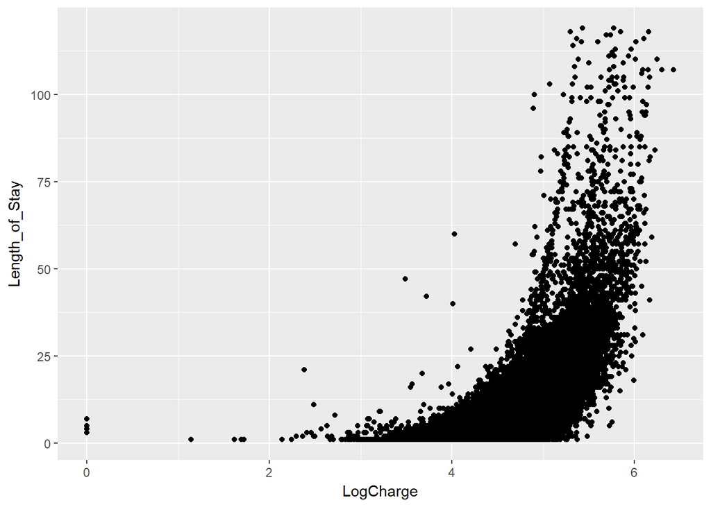

```r
ggplot(ipd_train, aes( x = LogCharge, y = Length_of_Stay)) +
  geom_point()
```

## Step 6 - Building and evaluation of predictive models

Now that you know a little more about the data, it's time to start building a few predictive models for `Total_Charges`. The error metric that we will use to evaluate the models (both for fit and for predictions) is **median absolute deviation** (MAD). This is nothing more than the median of the absolute value of the residuals for a fitted model.

**QUESTION:** What might be an advantage of using median absolute deviation instead of mean absolute deviation?

**ANSWER:** *The advantage of using the median rather than the mean is that the median is less likely to be skewed by outliers. Because the median shows the most frequent value, it may better represent the data.*

Obviously we want models with lower MAD values. Our ultimate goal is to create a model that predicts well on the test dataset, `ipd_test`.

### Null model

It's always a good idea to start out with what we call the *null model*. This is the simplest possible model and one that other models better be able to beat. For this regression problem, the null model is simply a regression model that just has a y-intercept. If you remember some of your statistics, you won't be surprised that the best fit value for the y-intercept in this case is the mean of the response variable, `Total_Charges`.

```r
charges_lm0 <- lm(Total_Charges ~ 1, data = ipd_train)
summary(charges_lm0)
```

```
##
## Call:
## lm(formula = Total_Charges ~ 1, data = ipd_train)
##
## Residuals:
##     Min      1Q  Median      3Q     Max
##  -41550  -28361  -17067    4885 2649697
##
## Coefficients:
##             Estimate Std. Error t value Pr(>|t|)
## (Intercept)    41551        172   241.5   <2e-16 ***
## ---
## Signif. codes:  0 '***' 0.001 '**' 0.01 '*' 0.05 '.' 0.1 ' ' 1
##
## Residual standard error: 63750 on 137319 degrees of freedom
```

```r
# Compute the MAD value
median(abs(charges_lm0$residuals))
```

```
## [1] 24376.3
```

It's not hard to create regression models with smaller MAD values than this. :)

Just to give you a benchmark, I built a model on the training set that had a MAD value of 7270.340. Again, this is just the median of the absolute values of the residuals of the fitted model. Later when I used this model on the test data, I got a MAD of ... well, I'll tell you a little later.

### Model building

Using the information you've gained from reading about the data and doing some EDA, build several regression models and compute the MAD from each. Summarize your results in terms of which model or models appear to fit well.

```r
charges_lm1 <- glm(Total_Charges ~ Health_Service_Area + Age_Group + Ethnicity + Type_of_Admission +
                    APR_Severity_of_Illness_Desc + Payment_Typology_1 + Length_of_Stay + APR_DRG_Code + ProcDone,
                  data = ipd_train, family=gaussian(link="identity"))
charges_lmlog <- glm(LogCharge ~ Health_Service_Area + Age_Group + Ethnicity + Type_of_Admission +
                      APR_Severity_of_Illness_Desc + Payment_Typology_1 + Length_of_Stay + APR_DRG_Code +
                      ProcDone,
                    data = ipd_train, family=gaussian(link="identity"))
charges_lmlog1 <- glm(LogCharge ~ Health_Service_Area + Age_Group + Ethnicity + Type_of_Admission +
                      APR_Risk_of_Mortality + Payment_Typology_1 + Length_of_Stay + APR_DRG_Code + ProcDone,
                    data = ipd_train, family=gaussian(link="identity"))
charges_lmlog2 <- glm(LogCharge ~ Health_Service_Area + Age_Group + Race + Type_of_Admission +
                      APR_Severity_of_Illness_Desc + Payment_Typology_1 + Length_of_Stay + APR_DRG_Code +
                      ProcDone,
                    data = ipd_train, family=gaussian(link="identity"))
charges_lmlog3 <- glm(LogCharge ~ Health_Service_Area + Age_Group + Ethnicity + Type_of_Admission +
                      APR_Severity_of_Illness_Desc + Payment_Typology_1 + log10(Length_of_Stay) + APR_DRG_Code + ProcDone,
                    data = ipd_train, family=gaussian(link="identity"))
charges_lmlog4 <- glm(LogCharge ~ Health_Service_Area + APR_Severity_of_Illness_Desc + log10(Length_of_Stay) + APR_DRG_Code +
                      ProcDone,
                    data = ipd_train, family=gaussian(link="identity"))
charges_lmsq <- glm(sqrt(Total_Charges) ~ Health_Service_Area + Age_Group + Ethnicity + Type_of_Admission +
                    APR_Severity_of_Illness_Desc + Payment_Typology_1 + Length_of_Stay + APR_DRG_Code +
                    ProcDone,
                  data = ipd_train, family=gaussian(link="identity"))
charges_lmsq1 <- glm(sqrt(Total_Charges) ~ Health_Service_Area + Age_Group + Ethnicity + Type_of_Admission +
                    APR_Severity_of_Illness_Desc + Payment_Typology_1 + log10(Length_of_Stay) + APR_DRG_Code +
                    ProcDone,
                  data = ipd_train, family=gaussian(link="identity"))
charges_lmsq2 <- glm(sqrt(Total_Charges) ~ Health_Service_Area + Age_Group + Ethnicity + Type_of_Admission +
                    APR_Severity_of_Illness_Desc + Payment_Typology_1 + sqrt(Length_of_Stay) + APR_DRG_Code +
                    ProcDone,
                  data = ipd_train, family=gaussian(link="identity"))

print(paste("lm1: ", median(abs(charges_lm1$residuals))))
```

```
## [1] "lm1:  8775.74475778234"
```

```r
print(paste("lmlog: ", median(abs(ipd_train$Total_Charges - 10**predict.glm(charges_lmlog,ipd_train)))))
```

```
## [1] "lmlog:  6908.0752385851"
```

```r
print(paste("lmlog1: ", median(abs(ipd_train$Total_Charges - 10**predict.glm(charges_lmlog1,ipd_train)))))
```

```
## [1] "lmlog1:  7020.91511008344"
```

```r
print(paste("lmlog2: ", median(abs(ipd_train$Total_Charges - 10**predict.glm(charges_lmlog2,ipd_train)))))
```

```
## [1] "lmlog2:  6924.8619181733"
```

```r
print(paste("lmlog3: ", median(abs(ipd_train$Total_Charges - 10**predict.glm(charges_lmlog3,ipd_train)))))
```

```
## [1] "lmlog3:  5322.04386713122"
```

```r
print(paste("lmlog4: ", median(abs(ipd_train$Total_Charges - 10**predict.glm(charges_lmlog4,ipd_train)))))
```

```
## [1] "lmlog4:  5379.91501930881"
```

```r
print(paste("lmsq: ", median(abs(ipd_train$Total_Charges - predict.glm(charges_lmsq,ipd_train)**2))))
```

```
## [1] "lmsq:  6820.83862068289"
```

```r
print(paste("lmsq1: ", median(abs(ipd_train$Total_Charges - predict.glm(charges_lmsq1,ipd_train)**2))))
```

```
## [1] "lmsq1:  6728.84328055982"
```

```r
print(paste("lmsq2: ", median(abs(ipd_train$Total_Charges - predict.glm(charges_lmsq2,ipd_train)**2))))
```

```
## [1] "lmsq2:  5932.76781950271"
```

Identify your top 3 models in terms of lowest MAD values to use in the next part in which you'll use them to make predictions on the test dataset. #Top 3 Models

*1: lmlog3*

*2: lmlog4*

*3: lmsq2*

**HACKER EXTRA:** Use k-crossfold validation to select your top 3 models.

*Well, we tried. But because we transformed the dependent variable in some of our models, the output does not compare apples to apples. This was okay when comparing the MAD, because we were familiar with the formula and were able to calculate it the 'long way' and compare on the same scale. We do not know how to do it with k-crossfold or even if it is even possible. It is interesting to note, however, when comparing models that were similarly transformed, that lmsq (fourth output down) performed better than lmsq1 (fifth output down) in k-crossfold, but not in the MAD comparison (although they were close).*

```r
library(boot)
```

```r
kCVlm1 <- cv.glm(ipd_train, charges_lm1, K=5)
kCVlog3 <- cv.glm(ipd_train, charges_lmlog3, K=5)
kCVlog4 <- cv.glm(ipd_train, charges_lmlog4, K=5)
kCVsq <- cv.glm(ipd_train, charges_lmsq, K=5)
kCVsq1 <- cv.glm(ipd_train, charges_lmsq1, K=5)
kCVsq2 <- cv.glm(ipd_train, charges_lmsq2, K=5)

kCVlm1$delta
```

```
## [1] 1134323596 1133658601
```

```r
kCVlog3$delta
```

```
## [1] 0.03012424 0.03012057
```

```r
kCVlog4$delta
```

```
## [1] 0.03085935 0.03085725
```

```r
kCVsq$delta
```

```
## [1] 2060.467 2059.824
```

```r
kCVsq1$delta
```

```
## [1] 2108.718 2108.267
```

```r
kCVsq2$delta
```

```
## [1] 1686.594 1686.292
```